# **NBA 球员的薪金影响因素探究**

1900092825 方祝礼 光华管理学院

[figure not shown]

# **背景介绍**

[环球时报特约记者徐海客](https://world.huanqiu.com/article/9CaKrnKlqHB)于2019年指出，从全球体育范围来看，NBA是球员平均**年薪最高**的体育联赛。回溯过往，许许多多的顶级篮球运动员在签下了合同就成功转换身份，一个亿在他们的眼里就瞬间成为了一个小目标，如华盛顿子弹(奇才前身)和大前锋朱万·霍华德于1996年就签下了一份7年1.05亿美元的合同。与此同时，随着时代的演化，顶级篮球运动员的合同薪金的增速就如同火箭一般，一发不可收拾，颇为惊人。姚明于2006年和火箭签下的5年顶薪合同与2019年的开拓者当家球星利拉德的顶薪合同，相较之下，只能以**“怎么姚明才值7500万？”**一言代之。2020年全球受到了疫情的冲击，[雪糕](https://www.iimedia.cn/c460/71593.html)指出NBA为了应对疫情缘故所带来的资金短缺，采取了球员降薪25 %的策略，但虽如此，NBA球员的薪金仍旧[**居高不下**](https://m.hupu.com/nba/players/salaries#)。综上所述，本文所要探究的课题正是NBA球员的薪金影响因素。

# **数据的介绍与说明**

## **数据来源**

```r
NBA <- read.csv("NBADATA1.csv", header = TRUE)
head(NBA)
```

```
##   X.ปฟplayer.name       position position1 heigh weigh age experience
## 1   Stephen Curry shooting guard         4  1.91    86  29          7
## 2    LeBron James  power forward         3  2.03   113  32         13
## 3    Paul Millsap         center         1  2.03   112  32         10
## 4  Gordon Hayward  small forward         5  2.03   103  27          6
## 5   Blake Griffin         center         1  2.08   114  28          6
## 6      Kyle Lowry    point guard         3  1.85    89  31         10
##   frequency.of.participation duration.of.participation offensive.ability
## 1                         79                     33.38            31.933
## 2                         74                     37.75            36.140
## 3                         69                     33.95            22.712
## 4                         73                     34.45            25.382
## 5                         61                     34.03            27.488
## 6                         60                     37.40            29.350
##   defensive.ability has.the.player.been.selected.as.an.All.Star
```

[output cut: 27 more lines]

```r
str(NBA)
```

```
## 'data.frame':    397 obs. of  18 variables:
##  $ X.ปฟplayer.name                             : chr  "Stephen Curry" "LeBron James" "Paul Millsap" "Gordon Hayward" ...
##  $ position                                    : chr  "shooting guard" "power forward" "center" "small forward" ...
##  $ position1                                   : int  4 3 1 5 1 3 2 2 4 5 ...
##  $ heigh                                       : num  1.91 2.03 2.03 2.03 2.08 1.85 1.91 1.85 1.96 2.01 ...
##  $ weigh                                       : int  86 113 112 103 114 89 91 79 100 99 ...
##  $ age                                         : int  29 32 32 27 28 31 28 29 28 28 ...
##  $ experience                                  : int  7 13 10 6 6 10 8 9 7 7 ...
##  $ frequency.of.participation                  : int  79 74 69 73 61 60 81 69 81 74 ...
##  $ duration.of.participation                   : num  33.4 37.8 34 34.5 34 ...
##  $ offensive.ability                           : num  31.9 36.1 22.7 25.4 27.5 ...
##  $ defensive.ability                           : int  4 8 7 5 6 4 9 4 7 5 ...
##  $ has.the.player.been.selected.as.an.All.Star : chr  "yes" "yes" "yes" "yes" ...
##  $ has.the.player.been.selected.as.an.All.Star1: int  1 1 1 1 1 1 1 1 1 1 ...
##  $ team.winning.percentage                     : chr  "high" "high" "high" "high" ...
##  $ team.winning.percentage1                    : int  3 3 3 3 3 3 2 2 3 3 ...
##  $ market.value.of.the.team                    : chr  "high" "medium" "low" "medium" ...
##  $ market.value.of.the.team1                   : int  3 2 1 2 3 2 2 1 3 2 ...
##  $ player.salaries                             : int  3468 3329 3127 2973 2951 2870 2853 2853 2830 2774 ...
```

## **数据概况**

### **定量变量的分布概况**

```r
summary(NBA)
```

```
##  X.ปฟplayer.name      position           position1         heigh
##  Length:397         Length:397         Min.   :1.000   Min.   :1.750
##  Class :character   Class :character   1st Qu.:1.000   1st Qu.:1.960
##  Mode  :character   Mode  :character   Median :3.000   Median :2.010
##                                        Mean   :2.902   Mean   :2.011
##                                        3rd Qu.:4.000   3rd Qu.:2.080
##                                        Max.   :5.000   Max.   :2.210
##      weigh            age          experience    frequency.of.participation
##  Min.   : 73.0   Min.   :19.00   Min.   : 0.00   Min.   :21.00
##  1st Qu.: 91.0   1st Qu.:24.00   1st Qu.: 1.00   1st Qu.:53.00
##  Median :100.0   Median :27.00   Median : 4.00   Median :68.00
##  Mean   :100.2   Mean   :27.25   Mean   : 4.97   Mean   :62.88
##  3rd Qu.:109.0   3rd Qu.:30.00   3rd Qu.: 8.00   3rd Qu.:76.00
##  Max.   :132.0   Max.   :40.00   Max.   :18.00   Max.   :82.00
##  duration.of.participation offensive.ability defensive.ability
##  Min.   : 4.88             Min.   : 1.495    Min.   : 0.000
##  1st Qu.:15.95             1st Qu.: 6.666    1st Qu.: 1.000
##  Median :21.92             Median :10.217    Median : 2.000
##  Mean   :22.17             Mean   :12.116    Mean   : 2.914
##  3rd Qu.:28.87             3rd Qu.:15.724    3rd Qu.: 4.000
##  Max.   :37.75             Max.   :42.950    Max.   :12.000
##  has.the.player.been.selected.as.an.All.Star
##  Length:397
##  Class :character
##  Mode  :character
##
##
##
##  has.the.player.been.selected.as.an.All.Star1 team.winning.percentage
##  Min.   :0.0000                               Length:397
##  1st Qu.:0.0000                               Class :character
##  Median :0.0000                               Mode  :character
##  Mean   :0.1209
##  3rd Qu.:0.0000
##  Max.   :1.0000
##  team.winning.percentage1 market.value.of.the.team market.value.of.the.team1
##  Min.   :1.000            Length:397               Min.   :1.000
##  1st Qu.:1.000            Class :character         1st Qu.:1.000
##  Median :2.000            Mode  :character         Median :2.000
##  Mean   :2.023                                     Mean   :2.108
##  3rd Qu.:3.000                                     3rd Qu.:3.000
##  Max.   :3.000                                     Max.   :3.000
##  player.salaries
##  Min.   :   7.0
##  1st Qu.: 198.0
##  Median : 500.0
##  Mean   : 782.4
##  3rd Qu.:1175.0
##  Max.   :3468.0
```

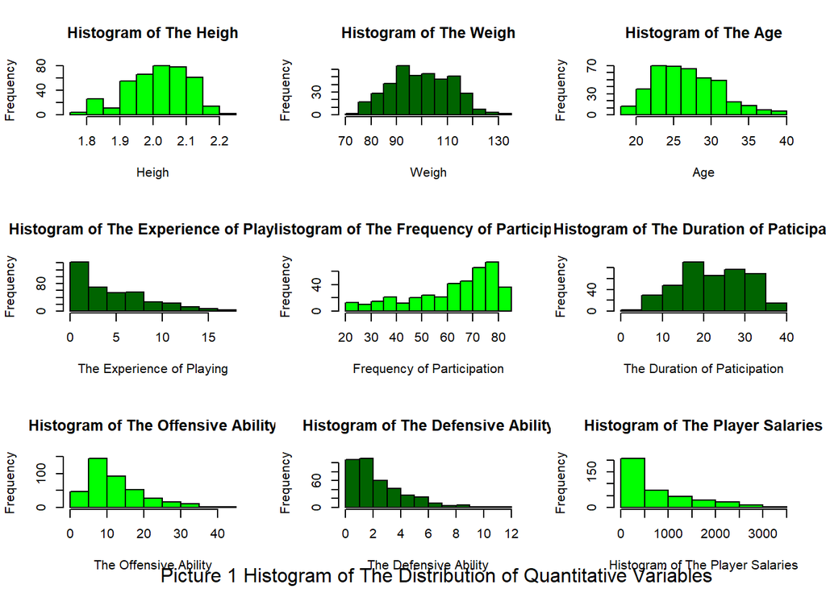

```
## named list()
```

```r
inipar <- par(no.readonly = T)
par(mfrow = c(3,3))
hist(NBA$heigh,main = "Histogram of The Heigh",xlab = "Heigh", col = "green")
hist(NBA$weigh, main = "Histogram of The Weigh", xlab = "Weigh", col = "darkgreen")
hist(NBA$age, main = "Histogram of The Age", xlab = "Age", col = "green")
hist(NBA$experience, main = "Histogram of The Experience of Playing", xlab ="The Experience of Playing", col = "darkgreen")
hist(NBA$frequency.of.participation, main = "Histogram of The Frequency of Participation", xlab = "Frequency of Participation", col ="green")
hist(NBA$duration.of.participation, main = "Histogram of The Duration of Paticipation", xlab ="The Duration of Paticipation", col ="darkgreen")
hist(NBA$offensive.ability, main = "Histogram of The Offensive Ability", xlab ="The Offensive Ability", col ="green")
hist(NBA$defensive.ability, main = "Histogram of The Defensive Ability", xlab ="The Defensive Ability" , col ="darkgreen")
hist(NBA$player.salaries, main = "Histogram of The Player Salaries", xlab ="Histogram of The Player Salaries", col ="green")
par(inipar)
par(title(sub = "Picture 1 Histogram of The Distribution of Quantitative Variables"))
```

**分析：** 由上图可见,身高变量、体重变量和场均时间变量的分布呈现出较好的对称性，这说明在这个数据集里的这三个变量没有过大的极大值或极小值，具体也可从这三个变量的均值与中位数之差看出，这两个值的差额并不大。然而，年龄变量、球龄变量、进攻能力变量、防守能力变量、球员薪金变量的分布都呈现出右偏分布，其三个变量的均值与中位数之差也较大，且均值大于中位数，这说明这三个变量都存有极大值。相对地，由于上场次数变的均值与中位数之差较大，且均值小于中位出，所以该类变量呈现出左偏分布，这说明在该类变量的数据集里含有极小值。

### **定性变量的频数概况**

```r
par(mfrow = c(2,3))
NBA$position = reorder(NBA$position, NBA$has.the.player.been.selected.as.an.All.Star, FUN = mean)
```

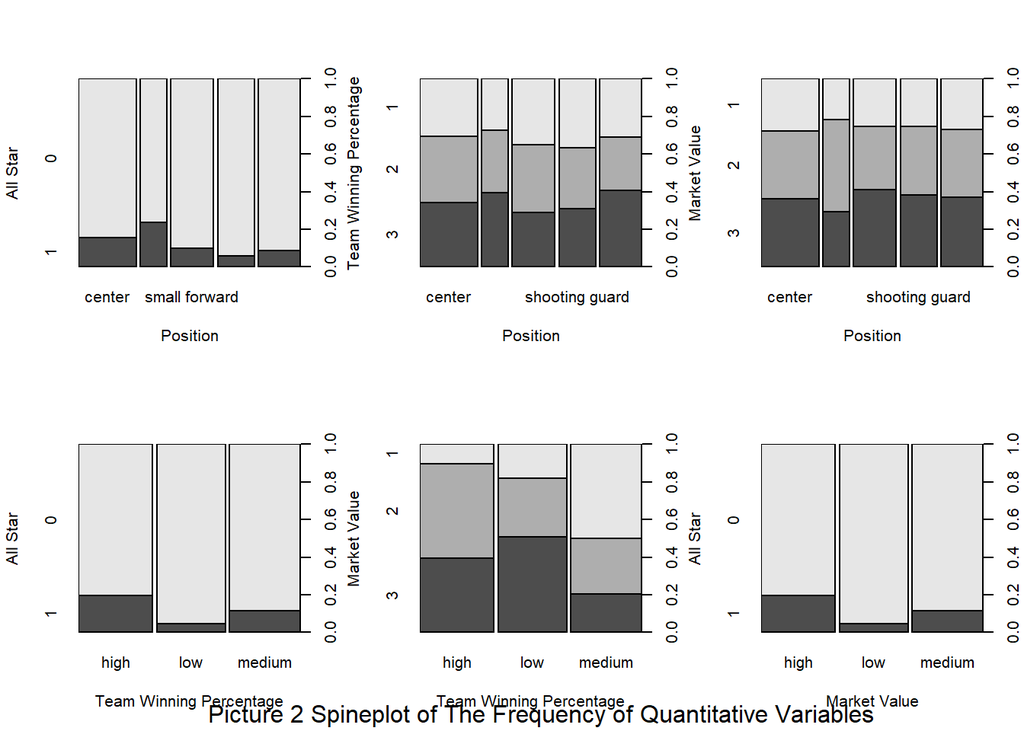

```
## named list()
```

```r
mylab = c("center","power forward","small forward","shooting guard","point guard")
spineplot(NBA$position, as.factor(NBA$has.the.player.been.selected.as.an.All.Star1), ylab = "All Star", xlab = "Position",
          xaxlabels = mylab)

NBA$position = reorder(NBA$position, NBA$team.winning.percentage, FUN = mean)
spineplot(NBA$position, as.factor(NBA$team.winning.percentage1), ylab = "Team Winning Percentage", xlab = "Position",
          )

NBA$position = reorder(NBA$position, NBA$market.value.of.the.team, FUN = mean)
spineplot(NBA$position, as.factor(NBA$market.value.of.the.team1), ylab = "Market Value", xlab = "Position",
)

NBA$team.winning.percentage = reorder(NBA$team.winning.percentage, NBA$has.the.player.been.selected.as.an.All.Star,FUN = mean)
spineplot(NBA$team.winning.percentage, as.factor(NBA$has.the.player.been.selected.as.an.All.Star1), ylab = "All Star", xlab ="Team Winning Percentage")

NBA$team.winning.percentage = reorder(NBA$team.winning.percentage, NBA$market.value.of.the.team,FUN = mean)
spineplot(NBA$team.winning.percentage, as.factor(NBA$market.value.of.the.team1), ylab = "Market Value", xlab ="Team Winning Percentage")

NBA$market.value.of.the.team1 = reorder(NBA$market.value.of.the.team, NBA$has.the.player.been.selected.as.an.All.Star,FUN = mean)
spineplot(NBA$team.winning.percentage, as.factor(NBA$has.the.player.been.selected.as.an.All.Star1), ylab = "All Star", xlab ="Market Value")
par(inipar)
par(title(sub = "Picture 2 Spineplot of The Frequency of Quantitative Variables"))
```

**分析：** 上方的棘状图组合图显示的是否入选过全明星变量、位置变量、球队胜率变量与球队市值变量的样本频数概况。从上图可见，对于是否入选过全明星的变量，大部分球员都没入选过，仅有少数的球员入选，尤其是身为前锋和具有高的球队胜率更有机会被入选为全明星。但是，在这数据集中，占比居多的却是属于前锋，但其球队胜率一般的。然而，具有中等水平的球队胜率往往具有较低的市值。

# **数据分析**

## **定性变量与球员薪金的相关性分析**

### **球员是否被选为全明星、球员位置与球员薪金的相关性探讨**

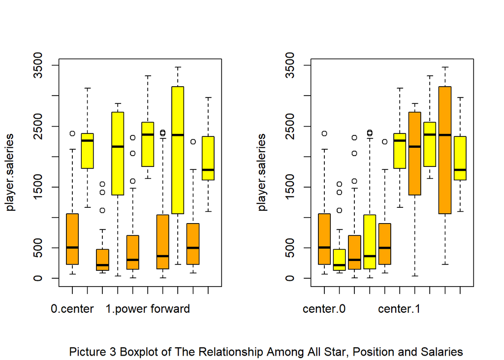

```
## named list()
```

```r
par(mfrow = c(1,2))
boxplot(NBA$player.salaries~NBA$has.the.player.been.selected.as.an.All.Star1:NBA$position,col = c("orange", "yellow")
        ,ylab = "player.saleries", xlab = "")
boxplot(NBA$player.salaries~NBA$position:NBA$has.the.player.been.selected.as.an.All.Star1,col = c("orange", "yellow")
        ,ylab = "player.saleries", xlab = "")
par(inipar)
par(title(sub = "Picture 3 Boxplot of The Relationship Among All Star, Position and Salaries"))
```

**分析:** 从上方的箱型图可看出，球员是否被选为全明星对得分后卫和大前锋的薪金具有较强的影响程度。

### **球员是否被选为全明星、球队胜率与球员薪金的相关性探讨**

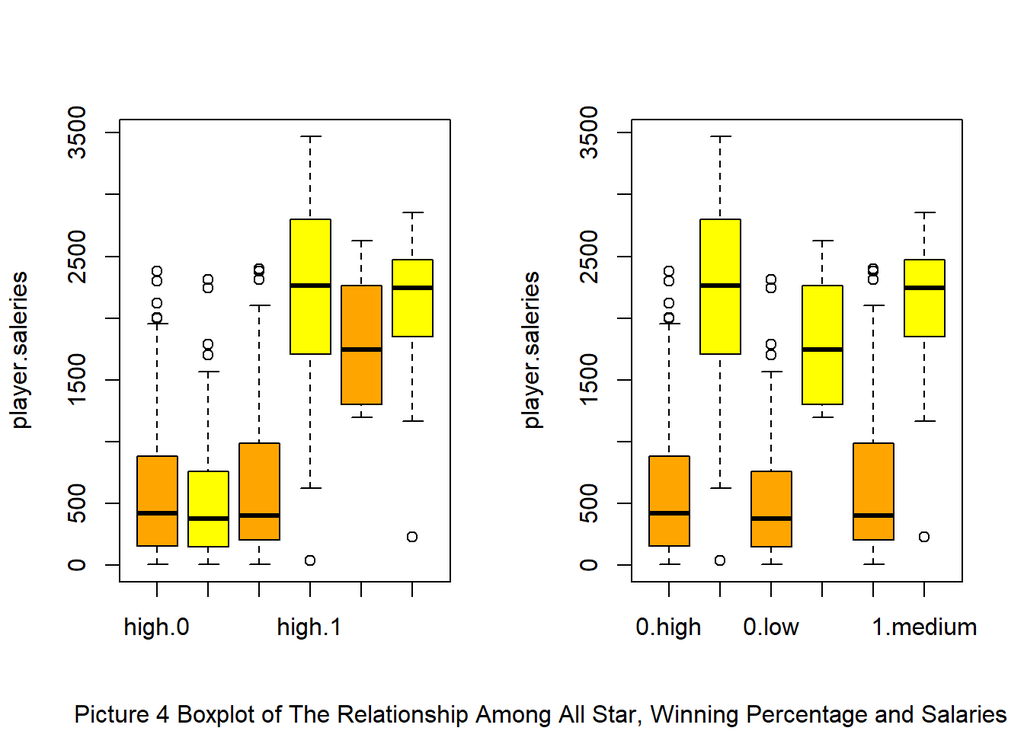

```
## named list()
```

```r
par(mfrow = c(1,2))
boxplot(NBA$player.salaries~NBA$team.winning.percentage:NBA$has.the.player.been.selected.as.an.All.Star1,col = c("orange", "yellow")
        ,ylab = "player.saleries", xlab = "")

boxplot(NBA$player.salaries~NBA$has.the.player.been.selected.as.an.All.Star1:NBA$team.winning.percentage,col = c("orange", "yellow")
        ,ylab = "player.saleries", xlab = "")
par(inipar)
par(title(sub = "Picture 4 Boxplot of The Relationship Among All Star, Winning Percentage and Salaries"))
```

**分析:** 从上方的箱型图可看出，具有高和一般胜利率的球队在被选为全明星后，其薪金都体现出较为大的增幅程度。

#### **小结**

总而言之，球员位置和球员是否被选为全明星与球员薪金具有相关性。当球员被选为全明星，其球员的薪金都会发生增幅现象，但其效果对身处于高和一般的球队胜率的得分后卫和大前锋较为明显。

## **定量变量与球员薪金的相关性分析**

### **球员身高与球员薪金的相关性探讨**

```r
Y = data.frame(NBA$heigh,NBA$weigh,NBA$age,NBA$experience,NBA$frequency.of.participation,NBA$duration.of.participation,NBA$offensive.ability,NBA$defensive.ability,NBA$player.salaries)
cor.test(Y$NBA.heigh,Y$NBA.player.salaries)
```

```
##
##  Pearson's product-moment correlation
##
## data:  Y$NBA.heigh and Y$NBA.player.salaries
## t = 1.3734, df = 395, p-value = 0.1704
## alternative hypothesis: true correlation is not equal to 0
## 95 percent confidence interval:
##  -0.02968197  0.16623527
## sample estimates:
##        cor
## 0.06894133
```

**分析:** 据相关性分析，球员身高与球员薪金的相关系数为 0.06894133，但其 p 值大于 0.05，无法拒绝原假设，意味着其相关性在统计学上不显著。

### **球员体重与球员薪金的相关性探讨**

```r
cor.test(Y$NBA.weigh,Y$NBA.player.salaries)
```

```
##
##  Pearson's product-moment correlation
##
## data:  Y$NBA.weigh and Y$NBA.player.salaries
## t = 2.8127, df = 395, p-value = 0.005158
## alternative hypothesis: true correlation is not equal to 0
## 95 percent confidence interval:
##  0.04228644 0.23530191
## sample estimates:
##       cor
## 0.1401251
```

**分析:** 据相关性分析，球员体重与球员薪金的相关系数为 0.1401251，且其 p 值小于 0.05，从而可以拒绝原假设，也就意味着其相关性在统计学上显著。

### **球员年龄与球员薪金的相关性探讨**

```r
cor.test(Y$NBA.age,Y$NBA.player.salaries)
```

```
##
##  Pearson's product-moment correlation
##
## data:  Y$NBA.age and Y$NBA.player.salaries
## t = 3.9997, df = 395, p-value = 7.573e-05
## alternative hypothesis: true correlation is not equal to 0
## 95 percent confidence interval:
##  0.1008255 0.2900789
## sample estimates:
##       cor
## 0.1972896
```

**分析:** 据相关性分析，球员年龄与球员薪金的相关系数为 0.1972896，且其 p 值远小于 0.05，从而可以拒绝原假设，也就意味着其相关性在统计学上显著。

### **球员球龄与球员薪金的相关性探讨**

```r
cor.test(Y$NBA.experience,Y$NBA.player.salaries)
```

```
##
##  Pearson's product-moment correlation
##
## data:  Y$NBA.experience and Y$NBA.player.salaries
## t = 6.5902, df = 395, p-value = 1.407e-10
## alternative hypothesis: true correlation is not equal to 0
## 95 percent confidence interval:
##  0.2232316 0.4007464
## sample estimates:
##       cor
## 0.3147385
```

**分析:** 据相关性分析，球员球龄与球员薪金的相关系数为 0.3147385，且其 p 值远小于 0.05，从而可以拒绝原假设，也就意味着其相关性在统计学上显著。

### **球员上场次数与球员薪金的相关性探讨**

```r
cor.test(Y$NBA.frequency.of.participation,Y$NBA.player.salaries)
```

```
##
##  Pearson's product-moment correlation
##
## data:  Y$NBA.frequency.of.participation and Y$NBA.player.salaries
## t = 7.0157, df = 395, p-value = 9.998e-12
## alternative hypothesis: true correlation is not equal to 0
## 95 percent confidence interval:
##  0.2423885 0.4176097
## sample estimates:
##       cor
## 0.3328693
```

**分析:** 据相关性分析，球员上场次数与球员薪金的相关系数为 0.3328693，且其 p 值远小于 0.05，从而可以拒绝原假设，也就意味着其相关性在统计学上显著。

### **球员场均时间与球员薪金的相关性探讨**

```r
cor.test(Y$NBA.duration.of.participation,Y$NBA.player.salaries)
```

```
##
##  Pearson's product-moment correlation
##
## data:  Y$NBA.duration.of.participation and Y$NBA.player.salaries
## t = 17.485, df = 395, p-value < 2.2e-16
## alternative hypothesis: true correlation is not equal to 0
## 95 percent confidence interval:
##  0.6011970 0.7126277
## sample estimates:
##       cor
## 0.6605344
```

**分析:** 据相关性分析，球员场均时间与球员薪金的相关系数为 0.6605344，且其 p 值远小于 0.05，从而可以拒绝原假设，也就意味着其相关性在统计学上显著。

### **球员进攻能力与球员薪金的相关性探讨**

```r
cor.test(Y$NBA.offensive.ability,Y$NBA.player.salaries)
```

```
##
##  Pearson's product-moment correlation
##
## data:  Y$NBA.offensive.ability and Y$NBA.player.salaries
## t = 19.375, df = 395, p-value < 2.2e-16
## alternative hypothesis: true correlation is not equal to 0
## 95 percent confidence interval:
##  0.6438635 0.7452691
## sample estimates:
##       cor
## 0.6980498
```

**分析:** 据相关性分析，球员进攻能力与球员薪金的相关系数为 0.6980498，且其 p 值远小于 0.05，从而可以拒绝原假设，也就意味着其相关性在统计学上显著。

### **球员防守能力与球员薪金的相关性探讨**

```r
cor.test(Y$NBA.defensive.ability,Y$NBA.player.salaries)
```

```
##
##  Pearson's product-moment correlation
##
## data:  Y$NBA.defensive.ability and Y$NBA.player.salaries
## t = 14.371, df = 395, p-value < 2.2e-16
## alternative hypothesis: true correlation is not equal to 0
## 95 percent confidence interval:
##  0.5173524 0.6470462
## sample estimates:
##      cor
## 0.585939
```

**分析:** 据相关性分析，球员防守能力与球员薪金的相关系数为 0.585939，且其 p 值远小于 0.05，从而可以拒绝原假设，也就意味着其相关性在统计学上显著。

### **定量变量与球员薪金的相关性总览**

```r
par(inipar)
cor.Y = cor(Y)
round(cor.Y, 2)
```

```
##                                NBA.heigh NBA.weigh NBA.age NBA.experience
## NBA.heigh                           1.00      0.83   -0.09          -0.05
## NBA.weigh                           0.83      1.00    0.05           0.10
## NBA.age                            -0.09      0.05    1.00           0.90
## NBA.experience                     -0.05      0.10    0.90           1.00
## NBA.frequency.of.participation     -0.01      0.03    0.02           0.08
## NBA.duration.of.participation      -0.10     -0.04    0.06           0.20
## NBA.offensive.ability              -0.13     -0.03    0.02           0.18
## NBA.defensive.ability               0.33      0.39    0.04           0.16
## NBA.player.salaries                 0.07      0.14    0.20           0.31
##                                NBA.frequency.of.participation
## NBA.heigh                                               -0.01
## NBA.weigh                                                0.03
## NBA.age                                                  0.02
## NBA.experience                                           0.08
## NBA.frequency.of.participation                           1.00
## NBA.duration.of.participation                            0.55
## NBA.offensive.ability                                    0.41
## NBA.defensive.ability                                    0.37
## NBA.player.salaries                                      0.33
##                                NBA.duration.of.participation
## NBA.heigh                                              -0.10
## NBA.weigh                                              -0.04
## NBA.age                                                 0.06
## NBA.experience                                          0.20
## NBA.frequency.of.participation                          0.55
## NBA.duration.of.participation                           1.00
## NBA.offensive.ability                                   0.86
## NBA.defensive.ability                                   0.68
## NBA.player.salaries                                     0.66
##                                NBA.offensive.ability NBA.defensive.ability
## NBA.heigh                                      -0.13                  0.33
## NBA.weigh                                      -0.03                  0.39
## NBA.age                                         0.02                  0.04
## NBA.experience                                  0.18                  0.16
## NBA.frequency.of.participation                  0.41                  0.37
## NBA.duration.of.participation                   0.86                  0.68
## NBA.offensive.ability                           1.00                  0.64
## NBA.defensive.ability                           0.64                  1.00
## NBA.player.salaries                             0.70                  0.59
##                                NBA.player.salaries
## NBA.heigh                                     0.07
## NBA.weigh                                     0.14
## NBA.age                                       0.20
## NBA.experience                                0.31
## NBA.frequency.of.participation                0.33
## NBA.duration.of.participation                 0.66
## NBA.offensive.ability                         0.70
## NBA.defensive.ability                         0.59
## NBA.player.salaries                           1.00
```

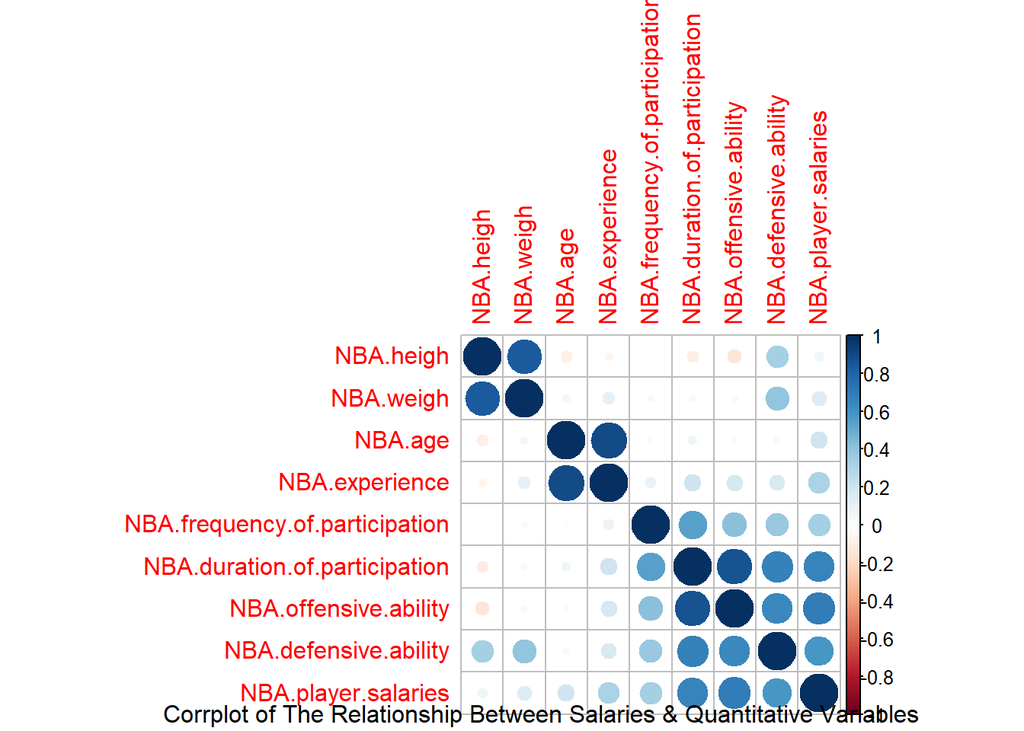

```
## named list()
```

```r
library(corrplot)
corrplot(cor.Y)
par(title(sub ="Corrplot of The Relationship Between Salaries & Quantitative Variables"))
```

# **结论**

综上所述，本文认为合同方在为球员设定一个薪金额时，所注重的是球员的进攻能力、耐力（场均时常），防守能力、上场次数和球龄。另外，球员是否被选为全明星、球员位置与球员薪金也具有相关性。

# **附录**

## **数据准备流程**

```r
nacheck <- as.vector(is.na(NBA))
for (i in nacheck){if(i == TRUE){print("TRUE")}}
```